# Git

Git is a distributed version contol system that is widely used to source code management

## 1. Git Installation

### Install Git

Go to the [Git](https://git-scm.com/) website to download the installer for your operation system

### Set up your account name and email address

You can specify Git configuration settings with the git config command

- [Setting your username in Git](https://docs.github.com/en/get-started/getting-started-with-git/setting-your-username-in-git)
- [Setting your commit email address](https://docs.github.com/en/account-and-profile/setting-up-and-managing-your-personal-account-on-github/managing-email-preferences/setting-your-commit-email-address)

```
## replace Nancy and Nancyteach@example.com with your username and email address.
git config --global user.name "Nancy"
git config --global user.email "Nancyteach@example.com"
```

To check your configuration, run the following command:

```
git config --global --list
```

## 2. Update Remote Repo

### Clone a remote repository to local computer

```
git clone <repository_url>
```

#### Update remote repository

Push change in local repository to remote repository (* do not include empty files (file size is 0) otherwise cause error) from step 1 - 3

1. To add files to the staging area, run the following command:

```
git add .
```

2. To commit the changes, run the following command. Repalce message with your comment to this commit

```
git commit -m 'message'
```

3. Push the change from local repository to remote repository

```
git push
```

### 3. Update local repository

Pull change from remote repository to local repository

```
git pull
```

## 4. Git large files

The image below indicated that file 'docs/app.json' exceeds file size limit, please follow below steps to resolve it.

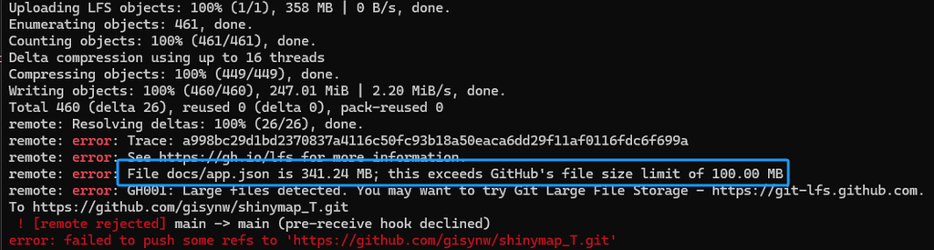

The error message: File docs/app.json is 341.24 MB; this exceeds GitHub's file size limit of 100.00 MB

- 1. Use below command to see which files are causing the push failure

```
git lfs migrate info
```

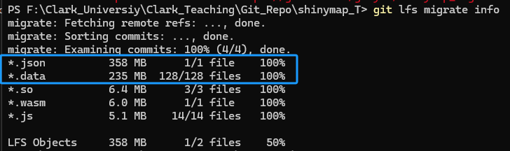

- 2. Git regular file limits the file size to 100 MB. So pull out the file over than 100 MB from history and store it in Git Large file.

```
git lfs migrate import --include="*.json"
git lfs migrate import --include="*.data"
```

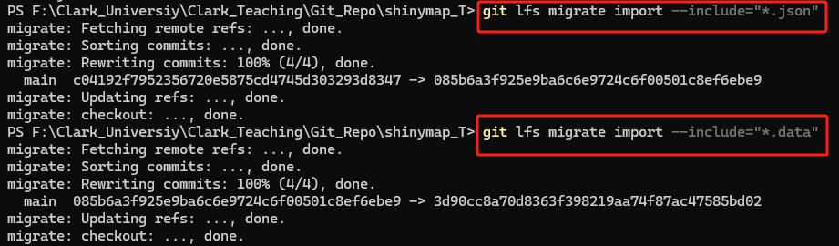

- 3. push the change

```
git push
```

#### You may have another error is relate to URL returned error. Then please use below command to increase buffer size

```
git config --global http.postBuffer 157286400
```

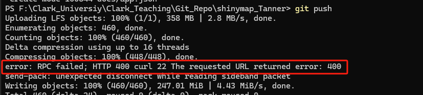

## Authentication error

1. Using personal access token (PAT) instead of your GitHub password
- generate a personal access token
  - go to github settings
  - Navigate to Developer settings > Personal access tokens > Tokens (classic) > Generate new token
- Update Git remote url

replace the password in your git remote url with the PAT you just generated - git remote set-url origin https://your-token@github.com/OWNER/REPOSITORY.git - Owner: your github user name - REPOSITORY: the name of the repository that you want to update

Thanks to Tanner Honnef for providing the solution!

2025-02-22 2025-02-22